# Temperatura JP x CG

```r
climas = read_csv(here::here("data/clima_cg_jp-semanal.csv"),
                  col_types = "cTdddddd")

glimpse(climas)
```

```
## Observations: 2,748
## Variables: 8
## $ cidade <chr> "Campina Grande", "Campina Grande", "Campina Grande", "...
## $ semana <dttm> 1992-12-27, 1993-01-03, 1993-01-10, 1993-01-31, 1993-0...
## $ tmedia <dbl> 26.13333, 26.11905, 25.76667, 25.74000, 26.31429, 26.28...
## $ tmax   <dbl> 30.4, 32.4, 32.2, 32.0, 32.7, 32.7, 32.3, 32.3, 32.1, 3...
## $ tmin   <dbl> 20.7, 19.3, 19.7, 19.9, 19.6, 20.0, 20.4, 21.2, 19.0, 1...
## $ chuva  <dbl> 0.0, 0.0, 0.0, 0.4, 0.3, 0.0, 4.9, 0.0, 0.0, 6.1, 0.4, ...
## $ mes    <dbl> 12, 1, 1, 1, 2, 2, 2, 2, 10, 11, 11, 11, 11, 12, 12, 12...
## $ ano    <dbl> 1992, 1993, 1993, 1993, 1993, 1993, 1993, 1993, 1993, 1...
```

## Temperatura

### Quais os meses mais quentes e mais frios?

Como esperado os meses de verão (Dezembro - março) são mais quentes, apresentando as maiores temperaturas máximas, médias e mínimas, para ambas as cidades. E os meses de inverno (Junho, Julho e Agosto) são os mais frios apresentando as menores temperaturas máximas, médias e mínimas para ambas as cidades.

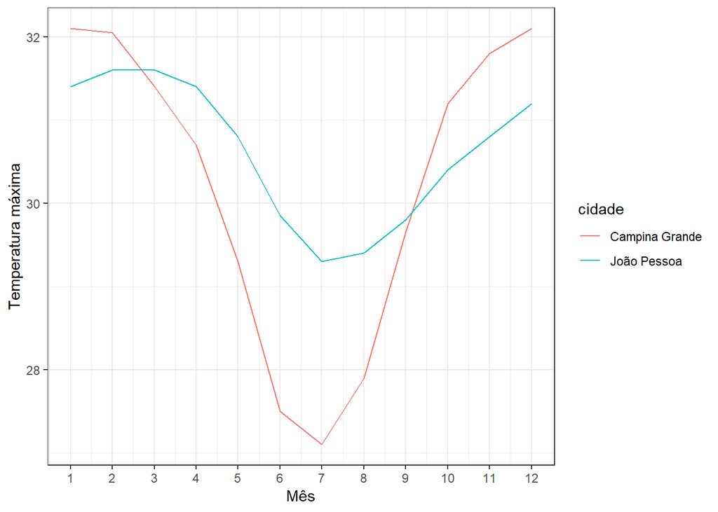

```r
climas %>%
  group_by(cidade, mes) %>%
  summarise(temp_max = median(tmax)) %>%
  ggplot(aes(x= mes,y = temp_max, colour = cidade)) +
  geom_line() +
  scale_x_continuous("Mês", breaks = seq(1,12,1)) +
  scale_y_continuous("Temperatura máxima", breaks = seq(20,40,2))
```

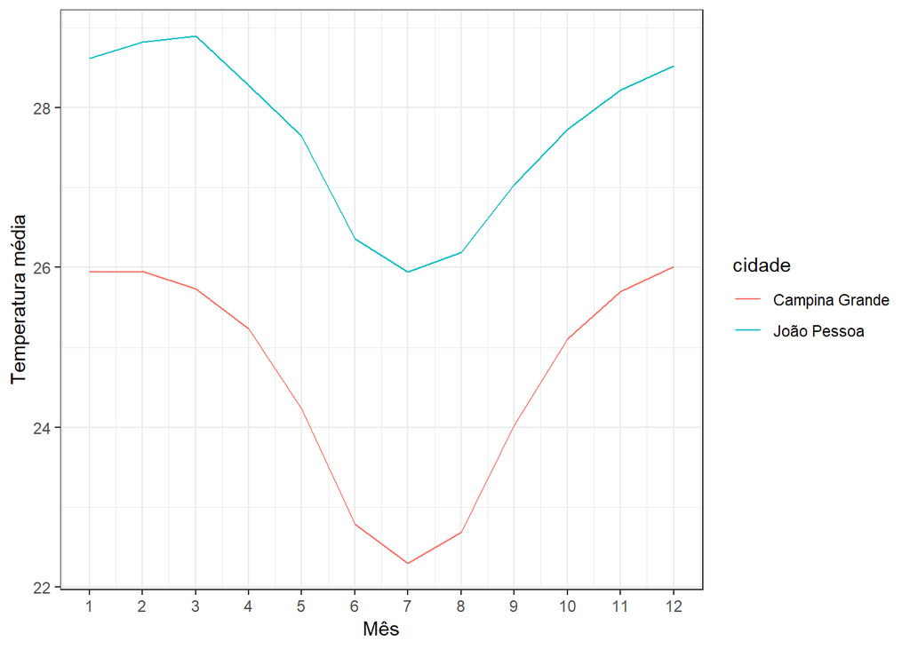

```r
climas %>%
  group_by(cidade, mes) %>%
  summarise(temp_media = median(tmedia)) %>%
  ggplot(aes(x= mes,y = temp_media, colour = cidade)) +
  geom_line() +
  scale_x_continuous("Mês", breaks = seq(1,12,1)) +
  scale_y_continuous("Temperatura média", breaks = seq(20,40,2))
```

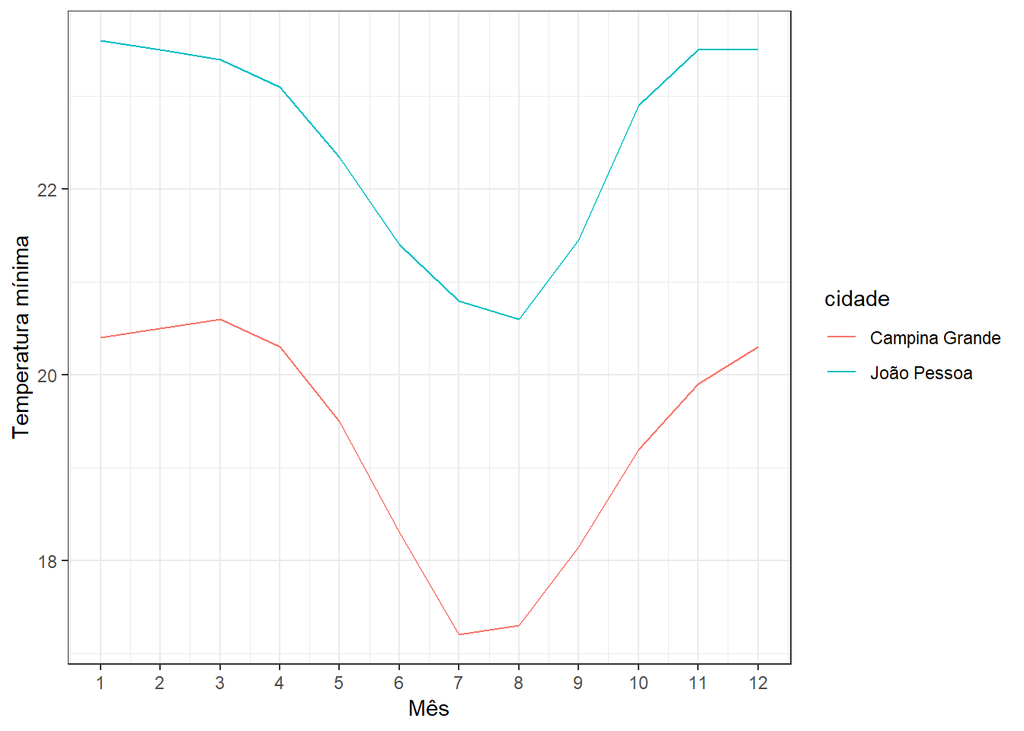

```r
climas %>%
  group_by(cidade, mes) %>%
  summarise(temp_minima = median(tmin)) %>%
  ggplot(aes(x= mes,y = temp_minima, colour = cidade)) +
  geom_line() +
  scale_x_continuous("Mês", breaks = seq(1,12,1)) +
  scale_y_continuous("Temperatura mínima", breaks = seq(0,30,2))
```

### Qual foi o São João mais frio de CG que está nos nossos dados?

Considerando o São João como o mês de Junho inteiro, temos que os anos de 2003, 2008, 2014, 2016 e 2018 tiveram as menores temperaturas mínimas (Entre 17.3 e 17.6). Dentre esses, anos 2008 foi o ano que teve também a menor temperatura média (22.2) e a menor máxima (26.8). Assim, podemos considerar o ano de 2008 como o São João mais frio de CG.

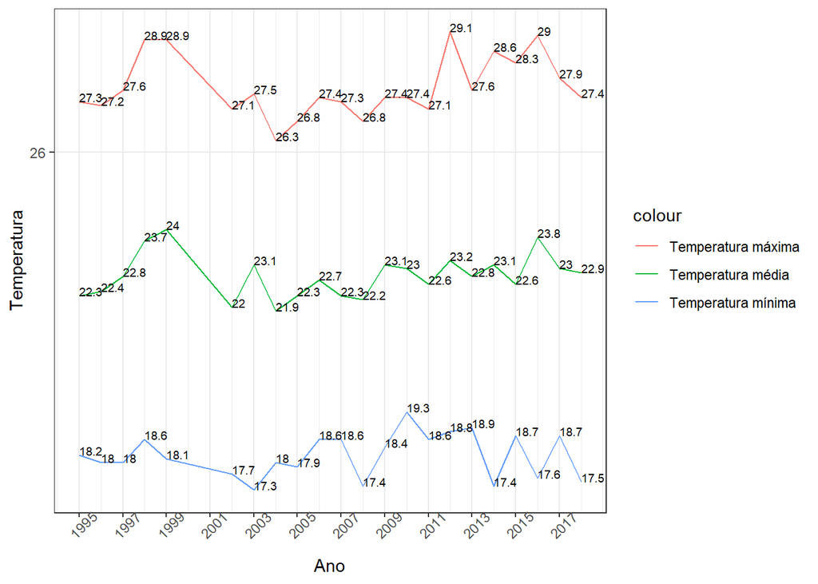

```r
climas %>%
  filter(cidade == "Campina Grande" & mes == 6) %>%
  group_by(ano) %>%
  summarise(temp_min = round(median(tmin),digits = 1), temp_max = round(median(tmax),digits = 1), temp_media = round(median(tmedia),digits = 1)) %>%
  ggplot() +
  geom_line(aes(x = ano, y = temp_max, colour = "Temperatura máxima")) +
  geom_text(aes(x = ano, y = temp_max,label=temp_max),hjust=0, vjust=0, size=2.5) +

  geom_line(aes(x = ano, y = temp_min, colour = "Temperatura mínima")) +
  geom_text(aes(x = ano, y = temp_min,label=temp_min),hjust=0, vjust=0, size=2.5) +

  geom_line(aes(x = ano, y = temp_media, colour = "Temperatura média")) +
  geom_text(aes(x = ano, y = temp_media, label=temp_media),hjust=0, vjust=0, size=2.5) +

  scale_x_continuous(breaks = seq(1995,2018,2)) +
  scale_y_continuous(breaks = seq(16,40,10)) +
  theme(axis.text.x = element_text(angle = 45))+
  labs(x = "Ano", y = "Temperatura")
```

## Chuva

### No geral, onde chove mais?

A partir da média de todos os registros de chuvas disponíveis, em João pessoa chove mais do que em Campina Gande.

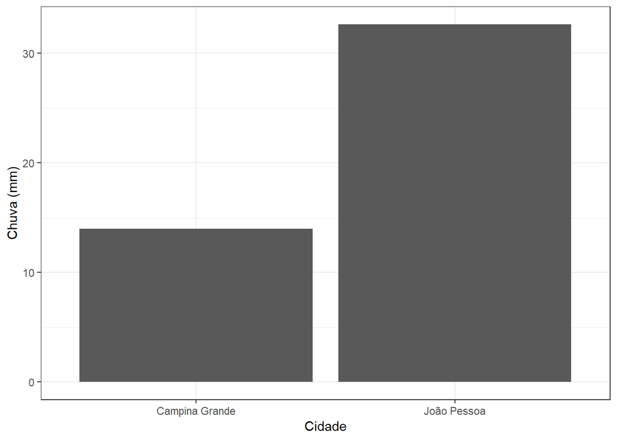

```r
climas %>%
  group_by(cidade) %>%
  summarise(total_chuva = mean(chuva)) %>%
  ggplot(aes(x=cidade,y = total_chuva)) +
  geom_col()  +
  labs(x = "Cidade", y = "Chuva (mm)")
```

### A distribuição é diferente em meses específicos?

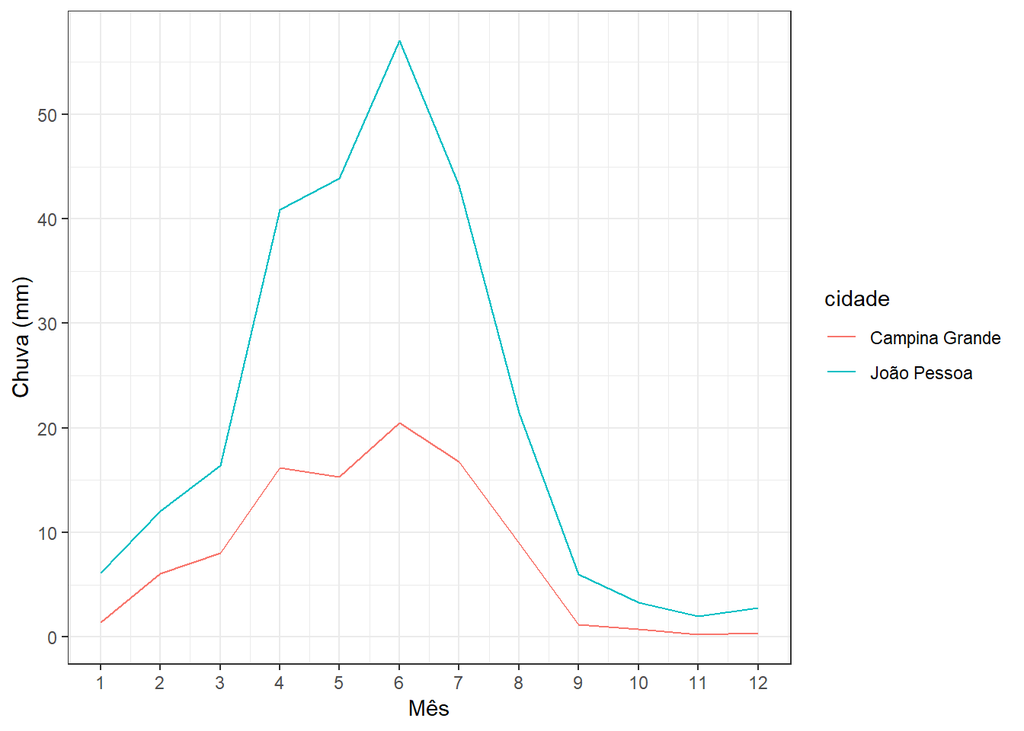

```r
climas %>%
  group_by(mes, cidade) %>%
  summarise(total_chuva = median(chuva)) %>%
  ggplot(aes(x= mes,y = total_chuva, colour = cidade)) +
  geom_line() +
  scale_x_continuous("Mês", breaks = seq(1,12,1)) +
  scale_y_continuous("Chuva (mm)", breaks = seq(0,100,10))
```